# Notebook

*N.B.* you will need to have the `skimage` librabry installed to run this. For this reason, I have separated out the cctbx and normal python bits. Once (if?) `cctbx` sorts out it's build system, we can do this all in one go.

```python
from __future__ import division
%matplotlib inline
```

## Import functions

Here are a few functions I wrote up to help with implementation. Region_based_seg does all the heavy lifting.

```python
from auto_detect_beamstop import clip_at_percentile, region_based_seg
```

## Get data

First, read in a bunch of pickles that contain numpy-converted image. I'm only doing this because `cctx.python` does not have a good way of adding modules, and it certainly doesn't suppoert `skimage`.

```python
import os
from cPickle import load

data_source = 'test_data_numpy'
files = os.listdir(data_source)
images = []
for f in files:
    im = load(open(os.path.join(data_source, f), 'rb'))
    images.append(clip_at_percentile(im, 99.9))
```

Now we have a list of clipped images, where we have set all pixels above the 99.9th percentile to the value at that percentile. This just deals with zingers/overloads. **Very important step, do not skip**

## Get segmentation for images

Why these params? See other notebook... I made a histogram of all test images, and intensities below 15 are clearly the beamstop. You might be able to tweak these further, but I think they're pretty good.

```python
segmentations = []
for im in images:
    segmentations.append(region_based_seg(im, low_thresh=15, high_thresh=35))
```

Let's visualize these:

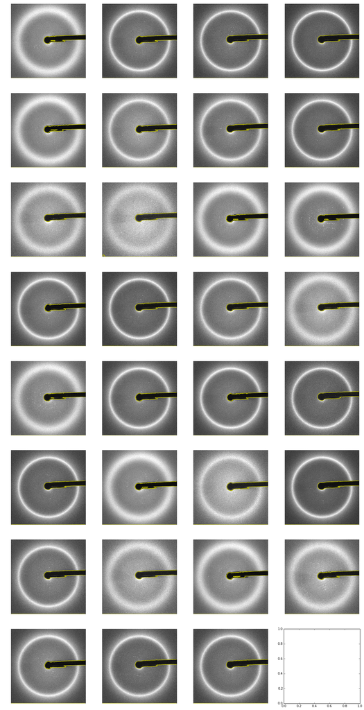

```python
from auto_detect_beamstop import plot_segmentation

# Ploting Foo
import matplotlib.pyplot as plt
fig, axes = plt.subplots(len(images) // 4 + 1, 4, figsize=(20,40))
axes = axes.flatten()

for im, seg, ax in zip(images, segmentations, axes):
    plot_segmentation(im, seg, ax)
```

Before we pat ourselves on the back, we need to export these again!

```python
from cPickle import dump
import numpy as np
for file, seg in zip(files, segmentations):
    dump(np.array(~seg, dtype=int), open("segmentation-" + file, 'wb')) # 0=Background, 1=Beamstop
```

This will write files looking like:

```python
!ls segmentation-*
```

```
segmentation-numpy-shot-s00-C5_0_00001_20140517135337549.pickle
segmentation-numpy-shot-s00-G5_0_00005_20140520132634826.pickle
segmentation-numpy-shot-s00-K7_0_00006_20140518123118514.pickle
segmentation-numpy-shot-s00-K7_0_00010_20140518123304533.pickle
segmentation-numpy-shot-s01-C5_0_00003_20140517135536896.pickle
segmentation-numpy-shot-s01-G5_0_00002_20140520132428047.pickle
segmentation-numpy-shot-s01-K7_0_00001_20140518122757591.pickle
segmentation-numpy-shot-s01-K7_0_00012_20140518123351620.pickle
segmentation-numpy-shot-s02-A1_0_00002_20140518141054243.pickle
segmentation-numpy-shot-s02-A1_0_00007_20140518141402260.pickle
segmentation-numpy-shot-s02-C5_0_00002_20140517135445508.pickle
segmentation-numpy-shot-s02-C5_0_00007_20140517140034704.pickle
segmentation-numpy-shot-s02-G5_0_00004_20140520132536483.pickle
segmentation-numpy-shot-s02-K7_0_00005_20140518123056243.pickle
segmentation-numpy-shot-s02-K7_0_00007_20140518123155295.pickle
segmentation-numpy-shot-s03-A1_0_00004_20140518141229980.pickle
segmentation-numpy-shot-s03-C5_0_00006_20140517135953983.pickle
segmentation-numpy-shot-s03-G5_0_00006_20140520132708855.pickle
segmentation-numpy-shot-s03-G5_0_00007_20140520132736091.pickle
segmentation-numpy-shot-s03-K7_0_00004_20140518123024708.pickle
segmentation-numpy-shot-s03-K7_0_00011_20140518123329745.pickle
segmentation-numpy-shot-s04-C5_0_00004_20140517135712325.pickle
segmentation-numpy-shot-s04-G5_0_00001_20140520132332955.pickle
segmentation-numpy-shot-s04-K7_0_00003_20140518122937674.pickle
segmentation-numpy-shot-s04-K7_0_00008_20140518123220006.pickle
segmentation-numpy-shot-s05-A1_0_00003_20140518141155114.pickle
segmentation-numpy-shot-s05-C5_0_00005_20140517135831653.pickle
segmentation-numpy-shot-s05-D7_0_00003_20140517154628366.pickle
segmentation-numpy-shot-s05-G5_0_00003_20140520132507314.pickle
segmentation-numpy-shot-s05-K7_0_00002_20140518122849699.pickle
segmentation-numpy-shot-s05-K7_0_00009_20140518123241666.pickle
```

Finally, run a little `cctbx` script to turn these into the right bit of the image pickle. You want to get them into the field `'ACTIVE_AREAS'` of the image pickle. this is a `scitbx_array_family_flex_ext.int` object. in a cctbx script, import the flex librabry, then just make it from a numpy array. Ask Nick/Aaron or the CCTBXBB if this is troublesome.

*n.b. on performance* We have created some pretty massive arrays here (for ease of explanation). Things will run **much** faster if you do these one at a time, instead of holding all the images you want to convert in memory at the same time. i.e: 1. `cctbx` script to convert image pickle to numpy array.* 2. use the functions shown here to create a backstop numpy array, dump it. 3. `cctbx` script to read this boolean array, convert it to a `scitbx` flex array, and put it back into the pickle. **Ask Nick and Aaron for help**.

*here is the one I used:

```
from libtbx import easy_pickle as ep
import sys

if __name__ == '__main__':
  if len(sys.argv) != 2:
    print "takes only 1 argumenr"
    sys.exit()
  pck_file = sys.argv[1]
  new_name = "numpy-" + pck_file
  img_d = ep.load(pck_file)
  img_data = img_d['DATA'].as_numpy_array()
  ep.dump(new_name, img_data)
```